```python
import pandas as pd
import matplotlib.pyplot as plt
```

```python
df = pd.read_csv(r"C:\Users\LENOVO\Downloads\financial_analysis_2023_2025.csv")

print(df)
```

```
     Company  Year Total Revenue Net Income Total Assets Total Liabilities  \
0  Microsoft  2023      2,11,915     72,361     4,11,976          2,05,753
1  Microsoft  2024      2,45,122     88,136     5,12,163          2,43,686
2  Microsoft  2025      2,81,724   1,01,832     6,19,003          2,75,524
3      Tesla  2023        96,773     14,974     1,06,618            43,009
4      Tesla  2024        97,690      7,153     1,22,070            48,390
5      Tesla  2025        94,827      3,855     1,37,806            54,941
6      Apple  2023      3,83,285     96,995     3,52,583          2,90,437
7      Apple  2024      3,91,035     93,736     3,64,980          3,08,030
8      Apple  2025      4,16,161   1,12,010     3,59,241          2,85,508

  Cash Flow
0    87,582
1  1,18,548
2  1,36,162
3    13,256
4    14,923
5    14,747
6  1,10,543
7  1,18,254
8  1,11,482
```

```python
cols = ['Total Revenue', 'Net Income', 'Total Assets', 'Total Liabilities', 'Cash Flow']

for col in cols:
    df[col] = df[col].astype(str).str.replace(',', '')
    df[col] = pd.to_numeric(df[col])

print(df.dtypes)
```

```
Company              object
Year                  int64
Total Revenue         int64
Net Income            int64
Total Assets          int64
Total Liabilities     int64
Cash Flow             int64
dtype: object
```

```python
# Revenue Growth
df['Revenue Growth (%)'] = df.groupby('Company')['Total Revenue'].pct_change() * 100

# Net Income Growth
df['Net Income Growth (%)'] = df.groupby('Company')['Net Income'].pct_change() * 100

# Profit Margin
df['Profit Margin (%)'] = (df['Net Income'] / df['Total Revenue']) * 100

# Debt Ratio
df['Debt Ratio (%)'] = (df['Total Liabilities'] / df['Total Assets']) * 100

print(df)
```

```
     Company  Year  Total Revenue  Net Income  Total Assets  \
0  Microsoft  2023         211915       72361        411976
1  Microsoft  2024         245122       88136        512163
2  Microsoft  2025         281724      101832        619003
3      Tesla  2023          96773       14974        106618
4      Tesla  2024          97690        7153        122070
5      Tesla  2025          94827        3855        137806
6      Apple  2023         383285       96995        352583
7      Apple  2024         391035       93736        364980
8      Apple  2025         416161      112010        359241

   Total Liabilities  Cash Flow  Revenue Growth (%)  Net Income Growth (%)  \
0             205753      87582                 NaN                    NaN
1             243686     118548           15.669962              21.800417
2             275524     136162           14.932156              15.539621
```

[output cut: 17 more lines]

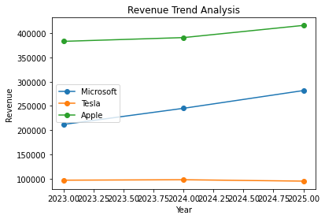

```python
for company in df['Company'].unique():

    company_data = df[df['Company'] == company]

    plt.plot(company_data['Year'],
             company_data['Total Revenue'],
             marker='o',
             label=company)

plt.title("Revenue Trend Analysis")
plt.xlabel("Year")
plt.ylabel("Revenue")
plt.legend()
plt.show()
```

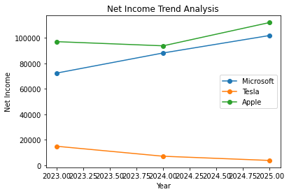

```python
for company in df['Company'].unique():

    company_data = df[df['Company'] == company]

    plt.plot(company_data['Year'],
             company_data['Net Income'],
             marker='o',
             label=company)

plt.title("Net Income Trend Analysis")
plt.xlabel("Year")
plt.ylabel("Net Income")
plt.legend()
plt.show()
```

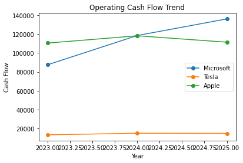

```python
for company in df['Company'].unique():

    company_data = df[df['Company'] == company]

    plt.plot(company_data['Year'],
             company_data['Cash Flow'],
             marker='o',
             label=company)

plt.title("Operating Cash Flow Trend")
plt.xlabel("Year")
plt.ylabel("Cash Flow")
plt.legend()
plt.show()
```

# Methodology

The financial data for Microsoft, Tesla, and Apple was manually extracted from SEC EDGAR 10-K filings for the years 2023 to 2025.

The extracted financial metrics include:

- Total Revenue
- Net Income
- Total Assets
- Total Liabilities
- Cash Flow from Operating Activities

The data was stored in a CSV file and analyzed using Python, pandas, and matplotlib in Jupyter Notebook.

# Revenue Trend Analysis

Apple recorded the highest revenue among all companies.

Microsoft showed strong and consistent revenue growth.

Tesla revenue remained mostly stable with a slight decline in 2025.

# Net Income Analysis

Microsoft and Apple showed strong profitability growth.

Apple achieved the highest net income in 2025.

Tesla experienced a significant decline in net income over the years.

# Cash Flow Analysis

Microsoft and Apple maintained strong operating cash flows.

Microsoft showed continuous cash flow growth from 2023 to 2025.

Tesla generated lower operating cash flow compared to Microsoft and Apple.

# Final Conclusion

This analysis compared the financial performance of Microsoft, Tesla, and Apple using SEC 10-K financial data from 2023 to 2025.

Microsoft and Apple demonstrated strong financial performance and stable growth.

Tesla maintained stable revenue but weaker profitability trends.

The project shows how Python can be used for financial trend analysis and AI-driven business insights.